# TP1 - Descriptive Statistics

Estimated time: **1** hour

In this lab, you'll go over some hands-on exercises using Python, based on what you have already learned about descriptive statistics, such as min, max, mean, median, standard deviation, etc. You will also learn how to plot informative statistical plots such as histogram, barplot, boxplot and make observations based on the data.

## Objectives

- Installation of Jupyter notebook
- Get familiar with the dataset
- Sample exercises
- Assignment questions
  - Obtain mean, median, standard deviation, percentile
  - Generate ECDF, histogram, barplot, boxplot, density plot
  - Other basic data analysis

# Get started with Jupyter Notebook

### Jupyter notebook runs code in a browser and includes an interactive Python interpreter and script editor.

#### You can use one of the online platforms to run the jupyter notebook

- Anaconda notebook: https://anaconda.cloud/code-in-the-cloud (**recommmended**)
- Kaggle notebook: https://www.kaggle.com/code
- Google colab: https://colab.research.google.com/

#### For advanced users, you can install Jupyter Notebook on your machine

1. **Install jupyter notebook**:  
   Follow the instructions at https://docs.jupyter.org/en/latest/install/notebook-classic.html to install jupyter notebook on your machine
2. **Run the notebook**:  
   Follow the instructions at https://docs.jupyter.org/en/latest/running.html to run the notebook

#### If you are not yet familar with Jupyter notebook, you can follow the tutorial video at: https://www.youtube.com/watch?v=HW29067qVWk&ab_channel=CoreySchafer to get an idea how does it work

## How to run the Jupyter notebook of the TP

#### If you are using the online platform, e.g. Anaconda

- Simply drop the two files: **TP1_Desriptive_Statistics.ipynb** and the two dataset (**ds_salaries.csv**, **DatasaurusSozen.tsv**) in the browser

#### If you run jupyter notebook on your machine

1. Start the command line
2. Go to the directory where the three files (**TP1_Desriptive_Statistics.ipynb**, **ds_salaries.csv**, and **DatasaurusSozen.tsv**) are
3. Start Jupyter notebook at the command line with: *jupyter notebook*

# Get familiar with the data set

### Import Libraries

#### Execute the following code to install libraries required for this lab.

```python
try:
    import numpy, pandas, seaborn, matplotlib, ipywidgets
    print("✅ numpy, pandas, seaborn, matplotlib, ipywidgets already installed")
except ImportError:
    !pip3 install -q numpy pandas seaborn matplotlib ipywidgets
    print("📦 Installed numpy, pandas, seaborn, matplotlib, ipywidgets")
```

```
✅ numpy, pandas, seaborn, matplotlib, ipywidgets already installed
```

#### Import the libraries needed for the lab

```python
import numpy as np
import pandas as pd
import seaborn as sns
import matplotlib.pyplot as plt
```

#### Read in the csv file

```python
df = pd.read_csv('ds_salaries.csv')
```

### Data Description

#### The dataset contains salaries for employees working in different data science fields. The individual field of the dataset is explained below:

| Variable | Description |
| --- | --- |
| **work_year** | The year the salary was paid. |
| **experience_level** | The experience level in the job during the year, possible values include: **EN**: Entry-level / Junior **MI**: Mid-level / Intermediate **SE**: Senior-level / Expert **EX**: Executive-level / Director |
| **employment_type** | The type of employement includes: **FT**: Full-time **PT**: Part-time **CT**: Contract **FL**: Freelance |
| **job_title** | The role worked in during the year |
| **salary** | The total gross salary amount paid |
| **salary_currency** | The currency of the salary paid as an ISO 4217 currency code |
| **salary_in_usd** | The salary in USD (FX rate divided by avg. USD rate of respective year) via statistical data from the BIS and central banks |
| **employee_residence** | Employee's primary country of residence during the work year as an ISO 3166 country code |
| **remote_ratio** | The overall amount of work done remotely, possible values include **0**: no remote work (less than 20%) **50**: partially remote/hybrid **100**: fully remote (more than 80%) |
| **company_location** | The country of the employer's main office or contracting branch as an ISO 3166 country code |
| **company_size** | The average number of people that worked for the company during the year **S**: less than 50 employees (small) **M**: 50 to 250 employees (medium) **L**: more than 250 employees (large) |

### Display the dataset

```python
df
```

|  | work_year | experience_level | employment_type | job_title | salary | salary_currency | salary_in_usd | employee_residence | remote_ratio | company_location | company_size |
| --- | --- | --- | --- | --- | --- | --- | --- | --- | --- | --- | --- |
| 0 | 2023 | SE | FT | Principal Data Scientist | 80000 | EUR | 85847 | ES | 100 | ES | L |
| 1 | 2023 | MI | CT | ML Engineer | 30000 | USD | 30000 | US | 100 | US | S |
| 2 | 2023 | MI | CT | ML Engineer | 25500 | USD | 25500 | US | 100 | US | S |
| 3 | 2023 | SE | FT | Data Scientist | 175000 | USD | 175000 | CA | 100 | CA | M |
| 4 | 2023 | SE | FT | Data Scientist | 120000 | USD | 120000 | CA | 100 | CA | M |
| ... | ... | ... | ... | ... | ... | ... | ... | ... | ... | ... | ... |
| 3750 | 2020 | SE | FT | Data Scientist | 412000 | USD | 412000 | US | 100 | US | L |
| 3751 | 2021 | MI | FT | Principal Data Scientist | 151000 | USD | 151000 | US | 100 | US | L |
| 3752 | 2020 | EN | FT | Data Scientist | 105000 | USD | 105000 | US | 100 | US | S |
| 3753 | 2020 | EN | CT | Business Data Analyst | 100000 | USD | 100000 | US | 100 | US | L |
| 3754 | 2021 | SE | FT | Data Science Manager | 7000000 | INR | 94665 | IN | 50 | IN | L |

3755 rows × 11 columns

### Get the number of rows and columns - prints as (number of rows, number of columns)

```python
df.shape
```

```
(3755, 11)
```

### Display the first and last ten rows of the data

```python
df.head(10)
```

|  | work_year | experience_level | employment_type | job_title | salary | salary_currency | salary_in_usd | employee_residence | remote_ratio | company_location | company_size |
| --- | --- | --- | --- | --- | --- | --- | --- | --- | --- | --- | --- |
| 0 | 2023 | SE | FT | Principal Data Scientist | 80000 | EUR | 85847 | ES | 100 | ES | L |
| 1 | 2023 | MI | CT | ML Engineer | 30000 | USD | 30000 | US | 100 | US | S |
| 2 | 2023 | MI | CT | ML Engineer | 25500 | USD | 25500 | US | 100 | US | S |
| 3 | 2023 | SE | FT | Data Scientist | 175000 | USD | 175000 | CA | 100 | CA | M |
| 4 | 2023 | SE | FT | Data Scientist | 120000 | USD | 120000 | CA | 100 | CA | M |
| 5 | 2023 | SE | FT | Applied Scientist | 222200 | USD | 222200 | US | 0 | US | L |
| 6 | 2023 | SE | FT | Applied Scientist | 136000 | USD | 136000 | US | 0 | US | L |
| 7 | 2023 | SE | FT | Data Scientist | 219000 | USD | 219000 | CA | 0 | CA | M |
| 8 | 2023 | SE | FT | Data Scientist | 141000 | USD | 141000 | CA | 0 | CA | M |
| 9 | 2023 | SE | FT | Data Scientist | 147100 | USD | 147100 | US | 0 | US | M |

```python
df.tail(10)
```

|  | work_year | experience_level | employment_type | job_title | salary | salary_currency | salary_in_usd | employee_residence | remote_ratio | company_location | company_size |
| --- | --- | --- | --- | --- | --- | --- | --- | --- | --- | --- | --- |
| 3745 | 2021 | SE | FT | Director of Data Science | 168000 | USD | 168000 | JP | 0 | JP | S |
| 3746 | 2021 | MI | FT | Data Scientist | 160000 | SGD | 119059 | SG | 100 | IL | M |
| 3747 | 2021 | MI | FT | Applied Machine Learning Scientist | 423000 | USD | 423000 | US | 50 | US | L |
| 3748 | 2021 | MI | FT | Data Engineer | 24000 | EUR | 28369 | MT | 50 | MT | L |
| 3749 | 2021 | SE | FT | Data Specialist | 165000 | USD | 165000 | US | 100 | US | L |
| 3750 | 2020 | SE | FT | Data Scientist | 412000 | USD | 412000 | US | 100 | US | L |
| 3751 | 2021 | MI | FT | Principal Data Scientist | 151000 | USD | 151000 | US | 100 | US | L |
| 3752 | 2020 | EN | FT | Data Scientist | 105000 | USD | 105000 | US | 100 | US | S |
| 3753 | 2020 | EN | CT | Business Data Analyst | 100000 | USD | 100000 | US | 100 | US | L |
| 3754 | 2021 | SE | FT | Data Science Manager | 7000000 | INR | 94665 | IN | 50 | IN | L |

# Sample Exercises

## Example-1: Find the mean, median, minimum, maximum values, standard deviation as well as the quantiles for salary in USD

### Find the mean, median, min, max value for salary in USD

```python
mean_salary = df['salary_in_usd'].mean()
median_salary = df['salary_in_usd'].median()
min_salary = df['salary_in_usd'].min()
max_salary = df['salary_in_usd'].max()

print(
    "mean: {:.0f}\n"
    "median: {:.0f}\n"
    "min: {:.0f}\n"
    "max: {:.0f}".format(mean_salary, median_salary, min_salary, max_salary)
)
```

```
mean: 137570
median: 135000
min: 5132
max: 450000
```

### Find the standard deviation and variance for salary in USD

#### The best-known estimates of variability are the *variance* and the *standard deviation*.

#### Variance

Variance is a measure of how far the values in a dataset are spread out from their mean. It is calculated as the average of the squared differences between each data point and the mean. Squaring the deviations ensures that all differences are positive and gives more weight to larger deviations.

$$ \large \text{Variance} \quad = \quad s^2 \quad = \quad \frac{\sum_{i=1}^{n} (x_i - \overline{x})^2}{n - 1} $$

#### Standard Deviation

Standard deviation is the square root of the variance, which brings the units back to the same scale as the data. A larger standard deviation indicates that the data points are more spread out from the mean.

$$ \large \text{Standard deviation} \quad s \quad = \quad \sqrt{\text{Variance}} $$

```python
salary_std = df['salary_in_usd'].std()
salary_var = df['salary_in_usd'].var()

print(
    "mean: {:.0f}\n"
    "variance: {:.0f}\n"
    "standard deviation: {:.0f}".format(mean_salary, salary_var, salary_std)
)
```

```
mean: 137570
variance: 3976011879
standard deviation: 63056
```

💪 **Quick test**: According to above result, **does the standard deviation indicate a small or large variation in the data relative to the mean?**

**Click to reveal the answer**

**Answer:**

The standard deviation indicates a **large variation** in the data relative to the mean.

**Explanation:**

The standard deviation (≈ 63,000) is nearly half of the mean (≈ 137,500). This suggests that the data points are spread widely around the mean, and there is substantial variability in the dataset.

If the standard deviation were much smaller compared to the mean, it would imply that the data points are clustered more tightly around the average.

### Find the 25th, 50th, 75th quantile

```python
quantile_25th = df['salary_in_usd'].quantile(0.25)
quantile_50th = df['salary_in_usd'].quantile(0.5)
quantile_75th = df['salary_in_usd'].quantile(0.75)

print(
    "25th percentile (Q1): {:.0f}\n"
    "50th percentile (Median): {:.0f}\n"
    "75th percentile (Q3): {:.0f}".format(quantile_25th, quantile_50th, quantile_75th)
)
```

```
25th percentile (Q1): 95000
50th percentile (Median): 135000
75th percentile (Q3): 175000
```

**25th percentile (Q1) = 95,000 → 25% of the data values are below 95,000, and 75% are above.**

💪 **Quick test**: Based on the quartiles (Q1 = 95,000; Q3 = 175,000), **what is the interquartile range (IQR), and what does it tell us about the data spread?**

**Click to reveal the answer**

**Answer:**

The interquartile range (IQR) is **80,000**.

**Explanation:**

The IQR is calculated as Q3 – Q1 = 175,000 – 95,000 = 80,000. It represents the range of the middle 50% of the data values. In this case, half of the salaries fall within an 80,000 range, between 95,000 and 175,000.

A larger IQR indicates greater variability in the central portion of the data, while a smaller IQR would mean the middle 50% of the data is more tightly clustered.

## Example-2: Produce a descriptive statistics table for salary in USD

```python
df['salary_in_usd'].describe()
```

```
count      3755.000000
mean     137570.389880
std       63055.625278
min        5132.000000
25%       95000.000000
50%      135000.000000
75%      175000.000000
max      450000.000000
Name: salary_in_usd, dtype: float64
```

As we can see, describe() gives the same information as above

#### Histograms are used to display the distribution of observed data. The data is divided into intervals (or "bins"), and the frequency (or count) of data points within each interval is represented by the height of the bars.

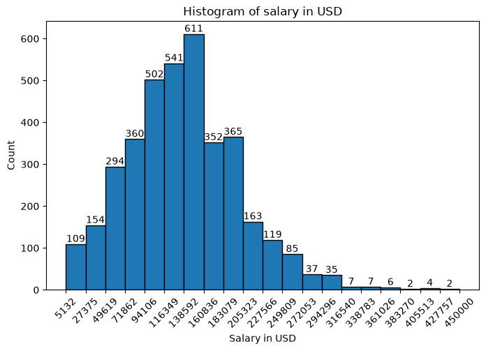

```python
plt.figure(figsize=(8, 5))

# Plot the histogram of salary in USD using 10 bins, with the edge of each bin in black
counts, bins, patches = plt.hist(df['salary_in_usd'], bins=20, edgecolor='black')

# Display the counts on top of each bar
for count, patch in zip(counts, patches):
    # Get the x and y position of the top of each bar
    x = patch.get_x() + patch.get_width() / 2
    y = patch.get_height()
    # Place the count on top of each bar
    plt.text(x, y, int(count), ha='center', va='bottom')


# Use the bin edges as the xticks
plt.xticks(bins, rotation=45)
plt.xlabel("Salary in USD")
plt.ylabel("Count")
plt.title("Histogram of salary in USD")
plt.show()
```

As we can see, the majority of the salary falls within the range **94,000** and **180,000**, with a count of **1043 + 963 = 2006**. Given we have a total of **3755 data points**, this indicates about 2006/3755 = **53.4%** of data falling within this range

#### Add vertical lines corresponding to the Q1, Median, Q3 on the histogram

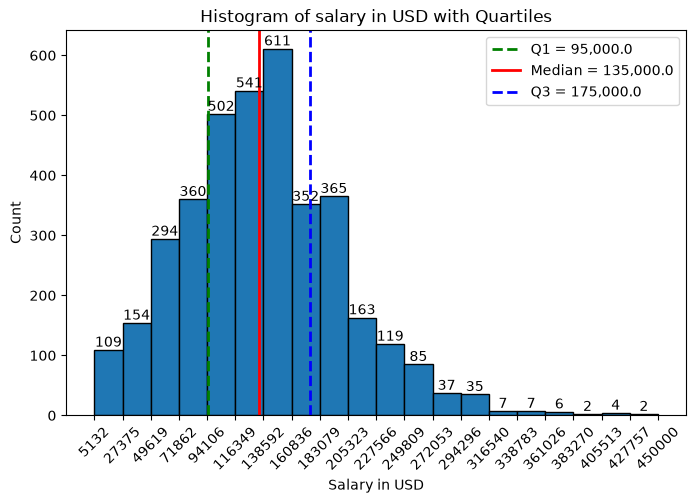

```python
# Quartiles
q1, median, q3 = quantile_25th, quantile_50th, quantile_75th

plt.figure(figsize=(8, 5))

# Plot histogram
counts, bins, patches = plt.hist(df['salary_in_usd'], bins=20, edgecolor='black')

# Display counts on top of bars
for count, patch in zip(counts, patches):
    x = patch.get_x() + patch.get_width() / 2
    y = patch.get_height()
    plt.text(x, y, int(count), ha='center', va='bottom')

# Overlay quartile lines
plt.axvline(q1, color='green', linestyle='--', linewidth=2, label=f"Q1 = {q1:,}")
plt.axvline(median, color='red', linestyle='-', linewidth=2, label=f"Median = {median:,}")
plt.axvline(q3, color='blue', linestyle='--', linewidth=2, label=f"Q3 = {q3:,}")

# Labels & title
plt.xticks(bins, rotation=45)
plt.xlabel("Salary in USD")
plt.ylabel("Count")
plt.title("Histogram of salary in USD with Quartiles")
plt.legend()
plt.show()
```

As previously mentioned, about half of the dataset (53.4%) falls between ~94,000 and ~180,000. This is quite closely aligned with the IQR range identified with Q1 and Q3.

#### Run the following code and play with different bin size

```python
from IPython.display import display, HTML

# Side-by-side interactive histogram with bin size legend
import matplotlib.pyplot as plt
import numpy as np
import ipywidgets as widgets
from IPython.display import display, clear_output

# --- Widgets: vertical bin choices ---
bin_choices = widgets.RadioButtons(
    options=[10, 30, 100],
    value=10,
    layout=widgets.Layout(width='200px')
)
controls = widgets.VBox([widgets.HTML("<b>Select bin size:</b>"), bin_choices])

# --- Output area for the plot ---
out = widgets.Output()
out.layout = widgets.Layout(width='800px')

def draw_hist(bins):
    with out:
        clear_output(wait=True)
        data = df['salary_in_usd'].dropna().values

        plt.figure(figsize=(8, 5))
        # Add a label to use in the legend
        counts, edges, patches = plt.hist(
            data, bins=bins, edgecolor='black', label=f"{bins} bins"
        )

        # Optional: counts on bars if bins are few
        if bins <= 30:
            for count, patch in zip(counts, patches):
                if count > 0:
                    x = patch.get_x() + patch.get_width() / 2
                    y = patch.get_height()
                    plt.text(x, y, f"{int(count)}", ha='center', va='bottom', fontsize=9)

        # Manage x-ticks
        max_ticks = 12
        if len(edges) <= max_ticks:
            xticks = edges
        else:
            step = max(1, len(edges) // max_ticks)
            xticks = edges[::step]
            if xticks[-1] != edges[-1]:
                xticks = np.append(xticks, edges[-1])

        plt.xticks(xticks, rotation=45)
        plt.xlabel("Salary in USD")
        plt.ylabel("Count")
        plt.title("Histogram of salary in USD")

        # Show legend with current bin size
        plt.legend(loc="upper right")

        plt.tight_layout()
        plt.show()

def on_bins_change(change):
    if change['name'] == 'value':
        draw_hist(change['new'])

bin_choices.observe(on_bins_change, names='value')

# Initial render
draw_hist(bin_choices.value)

# Display layout
ui = widgets.HBox([out, controls])
display(ui)
```

```
HBox(children=(Output(layout=Layout(width='800px')), VBox(children=(HTML(value='<b>Select bin size:</b>'), Rad…
```

💪 **Quick test**: Play with the different bin sizes by selecting them on the above interactive plot. Looking at the three histograms (with 10, 30, and 100 bins), **which bin size provides the most informative visualization of the salary distribution? Why?**

**Click to reveal the answer**

**Answer:**

The histogram with **30 bins** is the most informative.

**Explanation:**

- With **10 bins**, the distribution is oversimplified, and important details about the shape are hidden.  
- With **100 bins**, the histogram becomes too noisy, making it difficult to see the overall trend.  
- With **30 bins**, the plot balances detail and clarity: we can clearly see the central clustering (around 94k–180k) and still identify the spread and right tail without too much noise.

The choice of bin size affects how patterns in the data are revealed. A good bin size should show overall structure without losing important details.

## Example-4: generate the cumulative distribution of salary in USD for employees at SE (senior) level and MI (Mid-level), and show them in a single figure

#### The Seaborn *ecdfplot()* function can be used to plot the Empirical Cumulative Distribution Function(ECDF) of a dataset. The ECDF plot shows the proportion of data $x_i$ that fall below a certain value $x$ in a dataset.

$$ \large F(x) = \frac{1}{n} \sum_{i=1}^{n} 1_{\{x_i \leq x\}} $$

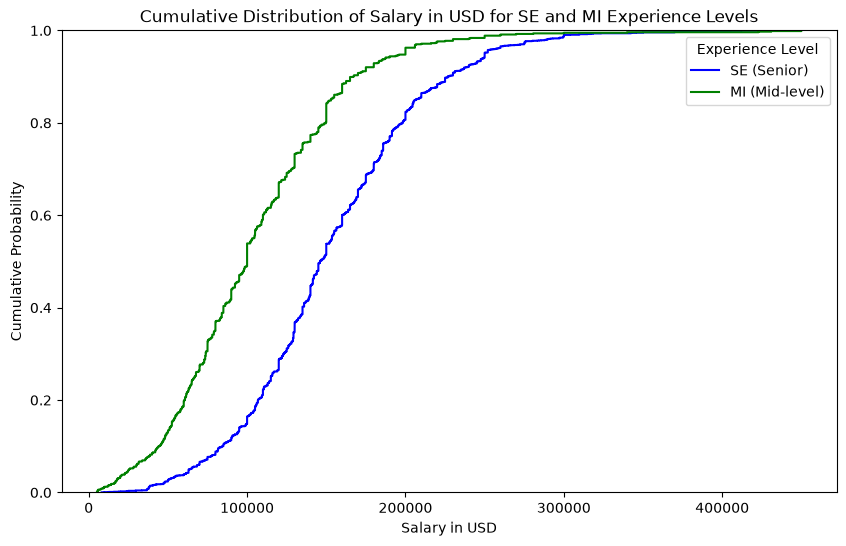

```python
# Filter the dataset for SE (Senior) and MI (Mid-level) experience levels
df_se = df[df['experience_level'] == 'SE']
df_mi = df[df['experience_level'] == 'MI']

# Create the ECDF plot
plt.figure(figsize=(10, 6))

# Plot the cumulative distribution for SE (Senior) experience level
sns.ecdfplot(data=df_se, x='salary_in_usd', label='SE (Senior)', color='blue')

# Plot the cumulative distribution for MI (Mid-level) experience level
sns.ecdfplot(data=df_mi, x='salary_in_usd', label='MI (Mid-level)', color='green')

# Add labels and title
plt.title('Cumulative Distribution of Salary in USD for SE and MI Experience Levels')
plt.xlabel('Salary in USD')
plt.ylabel('Cumulative Probability')

# Show the legend
plt.legend(title='Experience Level')

# Show the plot
plt.show()
```

💪 **Quick test**: According to the ECDF plot, **do senior-level (SE) employees have a larger or smaller proportion of people earning ≤ $100,000 compared to mid-level (MI) employees?**

**Click to reveal the answer**

**Answer:**

Senior-level (SE) employees have a **smaller** proportion earning ≤ $100,000 compared to mid-level (MI) employees.

**Explanation:**

On the ECDF, at \$100,000, the green line (MI) is much higher than the blue line (SE). This means a larger fraction of mid-level employees earn below \$100,000.

## Example-5: create the boxplot for salary in USD.

### A boxplot provides insightful information about the distribution of the data, such as the median, the 25th quartile, the 75th quartile, IQR, etc. The IQR gives a measure of spread for the middle half data and help understand the central tendency.

[figure not shown]

#### Execute the following code and generate the boxplot for salary in USD

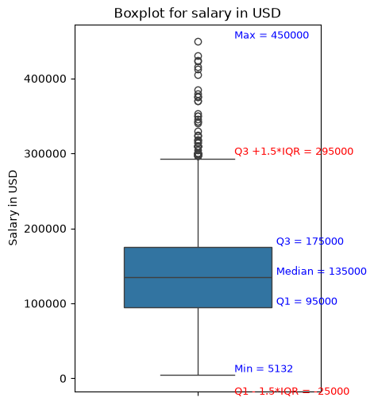

```python
import matplotlib.pyplot as plt
import seaborn as sns

plt.figure(figsize=(4, 6))

# Create a boxplot for 'salary_in_usd' with vertical orientation
sns.boxplot(y=df['salary_in_usd'], width=0.6)

# Calculate the quantiles
min_val = df['salary_in_usd'].min()
q1_val = df['salary_in_usd'].quantile(0.25)
median_val = df['salary_in_usd'].median()
q3_val = df['salary_in_usd'].quantile(0.75)
iqr = q3_val - q1_val
whisker_min = q1_val - 1.5 * iqr
whisker_max = q3_val + 1.5 * iqr
max_val = df['salary_in_usd'].max()

# Annotate directly at the correct y-positions
plt.text(x=0.15, y=min_val,     s=f'Min = {min_val:.0f}', ha='left', va='bottom', color='blue', fontsize=9)
plt.text(x=0.15, y=whisker_min, s=f'Q1 - 1.5*IQR = {whisker_min:.0f}', ha='left', va='bottom', color='red', fontsize=9)
plt.text(x=0.32, y=q1_val,      s=f'Q1 = {q1_val:.0f}', ha='left', va='bottom', color='blue', fontsize=9)
plt.text(x=0.32, y=median_val,  s=f'Median = {median_val:.0f}', ha='left', va='bottom', color='blue', fontsize=9)
plt.text(x=0.32, y=q3_val,      s=f'Q3 = {q3_val:.0f}', ha='left', va='bottom', color='blue', fontsize=9)
plt.text(x=0.15, y=whisker_max, s=f'Q3 +1.5*IQR = {whisker_max:.0f}', ha='left', va='bottom', color='red', fontsize=9)
plt.text(x=0.15, y=max_val,     s=f'Max = {max_val:.0f}', ha='left', va='bottom', color='blue', fontsize=9)

plt.ylabel("Salary in USD")
plt.title("Boxplot for salary in USD")
plt.show()
```

⚠️ Note: **each whisker's end goes to the farthest non-outlier point**. When computed with Q1-1.5*IQR, the theoretical "minimum" is -25000. However, the fathest non-outlier point, or in other words the minimum value of the dataset is 5132. Hence, it is used as the end of the whisker.

💪 **Quick test**: According to the boxplot, salaries above **295,000** (Q3 + 1.5 × IQR) are considered **outliers**. **True or False?**

**Click to reveal the answer**

**Answer:**

✅ True.

**Explanation:**

In a boxplot, any data point above **Q3 + 1.5 × IQR** or below **Q1 – 1.5 × IQR** is classified as an outlier.

Thus, salaries greater than 295,000 are plotted individually as outlier points (the circles above the upper whisker in the plot).

## Example-6: create the barplot for employee at different experience levels.

#### Bar plots are widely used to display and compare the frequency (or count) or other statistics of different categories. Each bar represents a distinct category.

#### First, let's generate a data frame which counts the number of employees at each experience level

```python
# Count the number of employees at each experience level
experience_counts = df['experience_level'].value_counts().reset_index()
experience_counts
```

|  | experience_level | count |
| --- | --- | --- |
| 0 | SE | 2516 |
| 1 | MI | 805 |
| 2 | EN | 320 |
| 3 | EX | 114 |

#### Execute the code and generate the bar plot

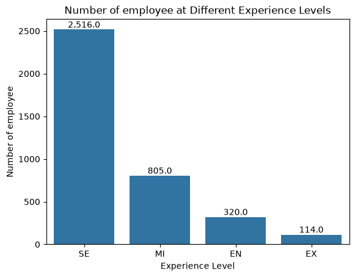

```python
# Create the bar plot
bar_plot = sns.barplot(x='experience_level', y='count', data=experience_counts)

# Add labels and title
plt.xlabel('Experience Level')
plt.ylabel('Number of employee')
plt.title('Number of employee at Different Experience Levels')

# Add the counts on top of each bar
for p in bar_plot.patches:
    bar_plot.annotate(format(p.get_height(), ','),
                      (p.get_x() + p.get_width() / 2, p.get_height()),
                      ha='center', va='bottom')

# Display the plot
plt.show()
```

#### According to the bar plot, we can see that

1. The majority of employees are at Senior level
2. Then followed by employee at Mid level, Entry level
3. Employee at Executive level is the least

## Example-7: create the pie chart for people at different experience level

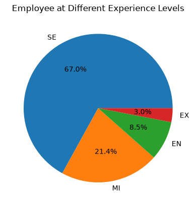

```python
# Count the number of employee at each experience level
experience_counts = df['experience_level'].value_counts()

# Plot the pie chart and display the percentage of employee at each experience level
plt.pie(experience_counts, labels=experience_counts.index, autopct='%.1f%%')
plt.title('Employee at Different Experience Levels')
plt.show()
```

According to the pie chart, it is even clearer that employees at Senior level represent the majority, whereas employees at Executive level represents the minority.

## Example-8: find the mode for the experience level variable

**Mode is the value that appears the most often**. We can use the pandas **mode()** function to find the mode for the experience level variable. From previous example exercise, we already know that the most frequently occured value is "SE". Run the following code to confirm it.

```python
# Find the mode for the 'experience_level' column
mode_experience_level = df['experience_level'].mode()
print(mode_experience_level)
```

```
0    SE
Name: experience_level, dtype: str
```

## Example-9: based on the dataset make some basic observations, e.g. does the median salary increase with time?

#### The following code groups the data by 'work_year' and computes the median salary for each group using the aggregation function 'median' applied to the 'salary_in_usd' column

```python
df.groupby('work_year').agg({'salary_in_usd':['median']}).reset_index()
```

|  | work_year | salary_in_usd median |
| --- | --- | --- |
| 0 | 2020 | 73065.0 |
| 1 | 2021 | 80000.0 |
| 2 | 2022 | 131300.0 |
| 3 | 2023 | 143860.0 |

#### According to the result, we can conclude that the median salary increases each year.

## Example-10: Importance of data visualization

#### The **Datasaurus Dozen** is a collection of 13 different datasets that all share nearly the same summary statistics (mean, standard deviation, etc.), but their scatterplots reveal very different shapes and patterns. It is commonly used to demonstrate the importance of visualization.

**Task:** Run the code below.

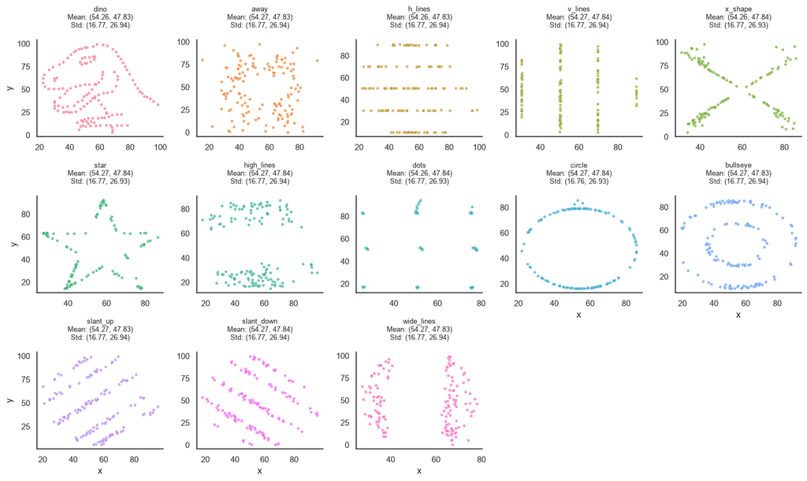

```python
# Load the datasaurus dataset
datasaurus = pd.read_csv('DatasaurusDozen.tsv', sep='\t')

# Remove grid, keep background white for cleaner plots.
sns.set(style="white")

# Plot the 13 datasets
# - col="dataset": each dataset gets its own subplot
# - col_wrap=5: wrap plots into rows of max 5 plots per row
# - hue="dataset": color each dataset consistently
# - sharex=False, sharey=False: allow each subplot to have its own x- and y-axis range
# - height=3: each subplot will be 3 inches tall
g = sns.FacetGrid(datasaurus, col="dataset", col_wrap=5, hue="dataset",
                  sharex=False, sharey=False, height=3)

# Map scatterplot onto each facet (small subplot)
# - s=15 sets the marker size
# - alpha=0.7 adds transparency so overlapping points are easier to see
g.map_dataframe(sns.scatterplot, x="x", y="y", s=15, alpha=0.7)
g.set_axis_labels("x", "y")

# Update titles to include dataset name, mean and std.
for ax, dataset_name in zip(g.axes.flat, datasaurus['dataset'].unique()):
    subset = datasaurus[datasaurus['dataset'] == dataset_name]
    mean_x = subset['x'].mean()
    mean_y = subset['y'].mean()
    std_x = subset['x'].std()
    std_y = subset['y'].std()

    ax.set_title(
        f"{dataset_name}\n"
        f"Mean: ({mean_x:.2f}, {mean_y:.2f})\n"
        f"Std: ({std_x:.2f}, {std_y:.2f})\n",
        fontsize=9
    )

plt.tight_layout()
plt.show()
```

For each subplot above, the title includes:

- The **dataset name** (e.g., `dino`, `circle`, `star`, etc.).
- The **mean** of the x and y values.
- The **standard deviation** of the x and y values.

💪 **Quick test**: Looking at the Datasaurus Dozen plots, **what do you observe about the summary statistics (mean, standard deviation, etc.) for each dataset? How do they compare to each other?**

**Click to reveal the answer**

**Answer:**

The summary statistics (mean and standard deviation of x and y) are almost **identical across all 13 datasets**.

**Explanation:**

Even though the numerical summaries are very similar, the actual shapes of the datasets are dramatically different — ranging from a dinosaur ("dino") to stars, circles, lines, and more.

This illustrates an important lesson: **summary statistics alone can be misleading**. Two datasets may have the same mean and standard deviation but look completely different when visualized. That's why visualizing and understanding pattern in data is important before drawing conclusions based solely on summary statistics.

# Assignment Questions [20 points]

### [2.5 points] Question-1: what is the mean, standard deviation, min, max, 25th quantile, 50th quantile, 75th quantile of salary in USD for full time employee resident in US

```python
us_residents = df[(df['employment_type'] == 'FT') & (df['employee_residence'] == 'US')]
us_residents['salary_in_usd'].describe()
```

```
count      2996.000000
mean     152872.664553
std       55018.033079
min       24000.000000
25%      115000.000000
50%      145000.000000
75%      185000.000000
max      450000.000000
Name: salary_in_usd, dtype: float64
```

### [3.5 points] Question-2: generate the cumulative distribution of salary in USD for employees at L (Large size) company and M (Middle size) company, and show them in a single figure

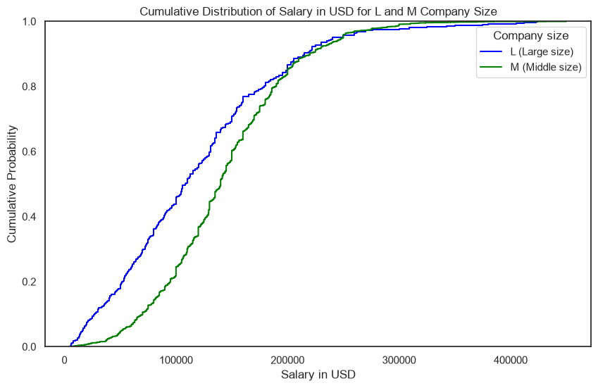

```python
## insert your code here
df_l = df[df['company_size'] == 'L']
df_m = df[df['company_size'] == 'M']

plt.figure(figsize=(10, 6))

sns.ecdfplot(data=df_l, x='salary_in_usd', label='L (Large size)', color='blue')

sns.ecdfplot(data=df_m, x='salary_in_usd', label='M (Middle size)', color='green')

plt.title('Cumulative Distribution of Salary in USD for L and M Company Size')
plt.xlabel('Salary in USD')
plt.ylabel('Cumulative Probability')

plt.legend(title='Company size')

plt.show()
```

#### Q2-2: Based on the ECDF plot above, answer whether the salary owned by employees working in large compancies dominant those in medium-sized company? Justify your answer based on the plot.

**Answer**: The salary owned by employees working in large companies is not dominant than the one of employees of middle companies because we can see in the plot that large company employees have cumulatively less salary.

### [2.5 points] Question-3: create a historgram of salary in USD for full time employee resident in US. The plot should contain 10 bins.

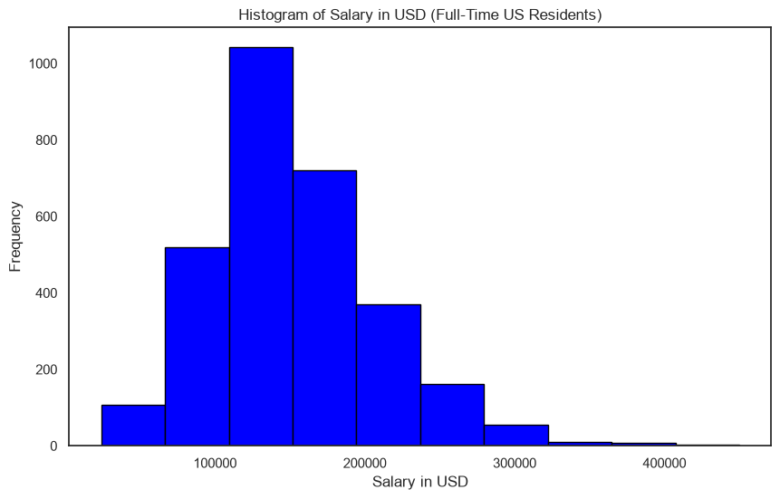

```python
## insert your code here


import matplotlib.pyplot as plt

us_ft_df = df[(df['employment_type'] == 'FT') & (df['employee_residence'] == 'US')]

plt.figure(figsize=(10,6))
plt.hist(us_ft_df['salary_in_usd'], bins=10, edgecolor='black', color='blue')

plt.title('Histogram of Salary in USD (Full-Time US Residents)')
plt.xlabel('Salary in USD')
plt.ylabel('Frequency')

plt.show()
```

### [3.5 points] Question-4: create a boxplot of salary in USD for full time employee at each experience level.

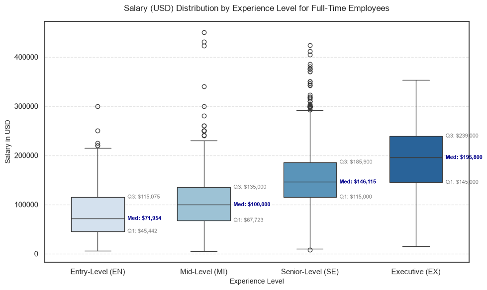

```python
import matplotlib.pyplot as plt
import seaborn as sns

df_ft = df[df["employment_type"] == "FT"].copy()

plt.figure(figsize=(10, 6))

exp_order = ["EN", "MI", "SE", "EX"]

ax = sns.boxplot(
    data=df_ft,
    x="experience_level",
    y="salary_in_usd",
    order=exp_order,
    palette="Blues",
    width=0.5,
)

for i, level in enumerate(exp_order):
    sub_data = df_ft[df_ft["experience_level"] == level]["salary_in_usd"]

    if sub_data.empty:
        continue

    q1_val = sub_data.quantile(0.25)
    median_val = sub_data.median()
    q3_val = sub_data.quantile(0.75)
    iqr = q3_val - q1_val
    whisker_min = sub_data[sub_data >= (q1_val - 1.5 * iqr)].min()
    whisker_max = sub_data[sub_data <= (q3_val + 1.5 * iqr)].max()

    ax.text(
        i + 0.28,
        median_val,
        f"Med: ${median_val:,.0f}",
        ha="left",
        va="center",
        fontsize=8,
        color="darkblue",
        weight="bold",
    )
    ax.text(
        i + 0.28,
        q1_val,
        f"Q1: ${q1_val:,.0f}",
        ha="left",
        va="center",
        fontsize=8,
        color="gray",
    )
    ax.text(
        i + 0.28,
        q3_val,
        f"Q3: ${q3_val:,.0f}",
        ha="left",
        va="center",
        fontsize=8,
        color="gray",
    )

plt.title(
    "Salary (USD) Distribution by Experience Level for Full-Time Employees",
    fontsize=12,
    pad=15,
)
plt.xlabel("Experience Level", fontsize=10)
plt.ylabel("Salary in USD", fontsize=10)
plt.xticks(
    ticks=[0, 1, 2, 3],
    labels=[
        "Entry-Level (EN)",
        "Mid-Level (MI)",
        "Senior-Level (SE)",
        "Executive (EX)",
    ],
)
plt.grid(axis="y", linestyle="--", alpha=0.5)
plt.tight_layout()

plt.show()
```

### [2.5 points] Question-5: create a pie chart for employees belonging to company of different sizes and answer which type of company represents the majority

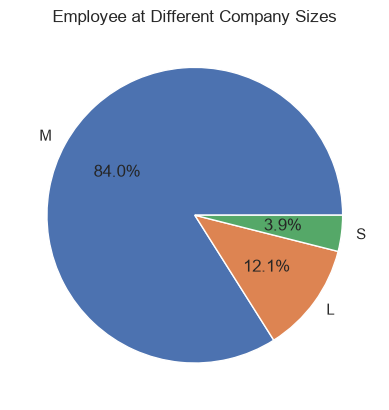

```
The majority of employees belong to company size: M
```

```python
## insert your code here
company_size_counts = df['company_size'].value_counts()

plt.pie(company_size_counts, labels=company_size_counts.index, autopct='%.1f%%')
plt.title('Employee at Different Company Sizes')
plt.show()

majority_size = company_size_counts.idxmax()
print(f"The majority of employees belong to company size: {majority_size}")
```

#### Q5-2: Based on the above pie plot, answer which type of company represents the majority. Justify your answer and support your answer with numeric values.

**Answer**: Based on the pie plot and the idmax() method, we can clearly see that the absolute majority (84.0%) of employees are represented by the Medium size companies.

### [2.5 points] Question-6: create a barplot for employees belonging to company of different sizes

```python
## insert your code here
company_size_counts_bar = df['company_size'].value_counts().reset_index()
company_size_counts_bar
```

|  | company_size | count |
| --- | --- | --- |
| 0 | M | 3153 |
| 1 | L | 454 |
| 2 | S | 148 |

### [3 points] Question-7: find the mode for the company size column and answer does it match the results shown in the bar plot above.

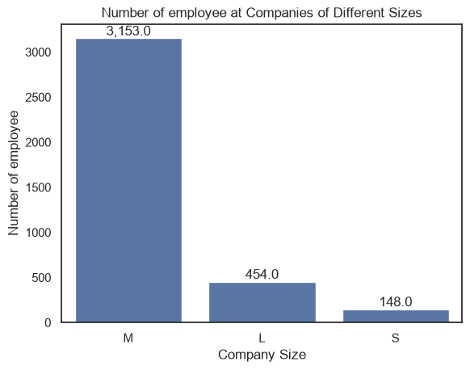

```python
## insert your code here
bar_plot = sns.barplot(x='company_size', y='count', data=company_size_counts_bar)

plt.xlabel('Company Size')
plt.ylabel('Number of employee')
plt.title('Number of employee at Companies of Different Sizes')

for p in bar_plot.patches:
    bar_plot.annotate(format(p.get_height(), ','),
                      (p.get_x() + p.get_width() / 2, p.get_height()),
                      ha='center', va='bottom')

plt.show()
```

```python
mode_company_size = df['company_size'].mode()
print(mode_company_size)
```

```
0    M
Name: company_size, dtype: str
```

#### Q7-2: Based on the result above, answer does it match the results shown in the bar plot in Question 6. Justify your answer.

**Answer**: The output of the .mode() function matches with the bar plot, both of them show that the majority of employyes are employed in the Medium sized companies.